# GEX Analysis (BCG Challenge 10X)

Emma Bishop

version March 27, 2024

# Intro

The goal is to tie this data together with findings from some of the other datasets:

- Blood bulk rna-seq
- Skin CyTOF

# Load libraries and data

```r
library(Seurat)
library(tidyverse)
library(CellChat)
library(svglite)
library(ggpubr)
library(cowplot)

set.seed(4)

# Whether to re-run cellchat or just load saved RDS object from last run
rerun_cellchat <- FALSE

# Top-level folder where script outputs should be stored
script_output_dir <- file.path(here::here(), "output")
```

```r
day3_annot <- readRDS(file = file.path(script_output_dir, "processed_data/9_final_annot_d3.rds"))
day15_annot <- readRDS(file = file.path(script_output_dir, "processed_data/9_final_annot_d15.rds"))
```

# Collapse annotations to match CyTOF groups

Define new annotations to match CyTOF cell types as best we can. I don’t think I can confidently label “cytotoxic” T cells.

```r
# Make CyTOF-related annotations that include non-immune cells

# For now don't worry about cytotoxic T cells (how would I define those?)
tcells <- c("CD8 TEM", "CD4 TEM", "dnT", "Treg", "CD8 Naive", "gdT",
            "CD4 Proliferating", "CD8 Proliferating")
mait <- c("MAIT")
tcm <- c("CD4 TCM", "CD8 TCM")
bcell <- c("B intermediate", "B memory", "B cells")
gran <- c("Mast cells")
mono <- c("CD14 Mono", "CD16 Mono")

# Day3
day3_annot@meta.data <- day3_annot@meta.data %>%
  mutate(cytof_annot = case_when(
    consolidated %in% tcells ~ "T cells",
    consolidated %in% mait ~ "MAIT cells",
    consolidated %in% tcm ~ "Tcm",
    consolidated %in% bcell ~ "B cells",
    consolidated %in% gran ~ "Granulocytes",
    consolidated %in% mono ~ "Monocytes",
    .default = eb_atlas_idents
  )) %>%
  mutate(cytof_annot = case_when(
    cytof_annot == "Lymphoid" ~ "Lymphoid other",
    cytof_annot == "Myeloid" ~ "Myeloid other",
    .default = cytof_annot
  ))

# Day15
day15_annot@meta.data <- day15_annot@meta.data %>%
  mutate(cytof_annot = case_when(
    consolidated %in% tcells ~ "T cells",
    consolidated %in% mait ~ "MAIT cells",
    consolidated %in% tcm ~ "Tcm",
    consolidated %in% bcell ~ "B cells",
    consolidated %in% gran ~ "Granulocytes",
    consolidated %in% mono ~ "Monocytes",
    .default = eb_atlas_idents
  )) %>%
  mutate(cytof_annot = case_when(
    cytof_annot == "Lymphoid" ~ "Lymphoid other",
    cytof_annot == "Myeloid" ~ "Myeloid other",
    .default = cytof_annot
  ))
```

Define colors

```r
clstr_colors_imm <- c("Lymphoid other" = "#00A9FF", "T cells"= "#00BFC4", "MAIT cells" = "cyan",
                  "Tcm" = "#8ab8fe", "B cells" = "navy", "Keratinocytes" = "#FF61CC",
                  "Epithelial" = "#0CB702", "Endothelial" = "#E68613",
                  "Muscle tissue" = "#C77CFF", "Connective tissue" = "#00BE67",
                  "Nervous tissue" = "#A52A2A", "Unknown" = "gray",
                  "Myeloid other" = "#F8766D", "Monocytes" = "#cb416b",
                  "Granulocytes" = "#f8481c")
```

Sanity check that these collapsed groupings make sense

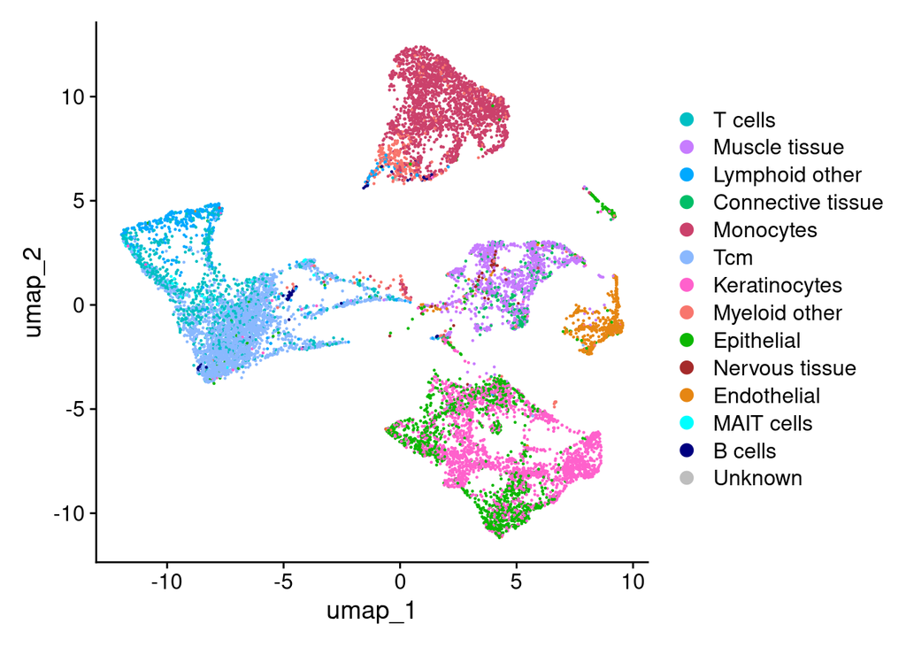

```r
Idents(day3_annot) <- "cytof_annot"
DimPlot(day3_annot, cols = clstr_colors_imm)
```

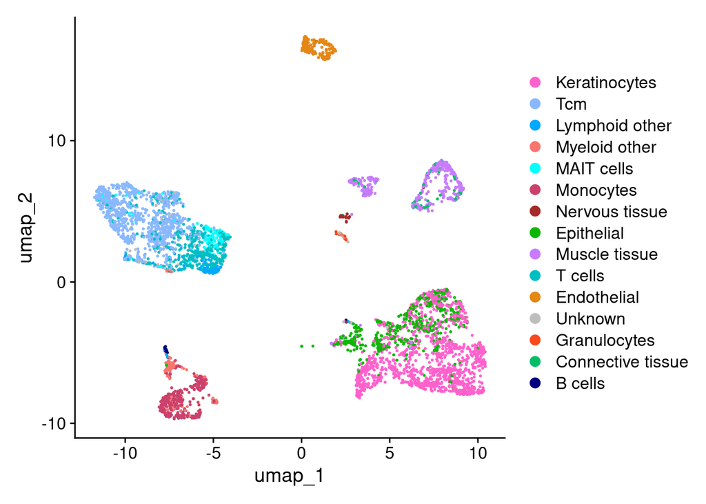

```r
Idents(day15_annot) <- "cytof_annot"
DimPlot(day15_annot, cols = clstr_colors_imm)
```

# Cell composition

In the CyTOF data we see changes in cell populations between days 3 and 15. We want to check if a similar pattern shows up in the single-cell data. Cell populations of interest (significantly different by unadj p-value):

- T cells (excluding MAIT, cytotoxic, CD11c+, Tcm): Down at D15
- Macrophages: Up at D15
- Granulocytes: Up at D15
- Monocytes: Down at D15

Make dataframes

```r
make_boxplot_df <- function(meta_df, major_pop, subpop_vec) {
  df1 <- meta_df %>%
    group_by(orig.ident, PTID) %>%
    filter(eb_atlas_idents == major_pop) %>%
    tally() %>%
    dplyr::rename(major_tot = n)

  # Total subtypes of interest per PTID
  df2 <- meta_df %>%
    group_by(orig.ident, PTID, cytof_annot) %>%
    filter(eb_atlas_idents == major_pop) %>%
    tally() %>%
    left_join(df1, by = c("orig.ident", "PTID")) %>%
    mutate(Frequency = n / major_tot * 100) %>%
    # Will only plot the analogous sub-populations
    filter(cytof_annot %in% subpop_vec) %>%
    mutate(cytof_annot = factor(cytof_annot, levels = subpop_vec))

  return(df2)
}

combined <- bind_rows(day3_annot@meta.data, day15_annot@meta.data)

lymph_df <- make_boxplot_df(combined, "Lymphoid", c("T cells", "MAIT cells", "Tcm", "B cells"))
myel_df <- make_boxplot_df(combined, "Myeloid", c("Monocytes", "Granulocytes"))

# Add 0's for granulocytes (not seen at day 3)
d3_gran <- data.frame(orig.ident = rep(c("Day3"), 9),
                      PTID = c("1", "5", "7", "8", "9", "10", "12", "13", "16"),
                      cytof_annot = c("Granulocytes"),
                      n = rep(c(0), 9),
                      major_tot = rep(c(NA), 9),
                      Frequency = rep(c(0), 9))
d3_gran
```

```
##   orig.ident PTID  cytof_annot n major_tot Frequency
## 1       Day3    1 Granulocytes 0        NA         0
## 2       Day3    5 Granulocytes 0        NA         0
## 3       Day3    7 Granulocytes 0        NA         0
## 4       Day3    8 Granulocytes 0        NA         0
## 5       Day3    9 Granulocytes 0        NA         0
## 6       Day3   10 Granulocytes 0        NA         0
## 7       Day3   12 Granulocytes 0        NA         0
## 8       Day3   13 Granulocytes 0        NA         0
## 9       Day3   16 Granulocytes 0        NA         0
```

```r
myel_df <- bind_rows(myel_df, d3_gran) %>%
  mutate(orig.ident = factor(orig.ident, levels = c("Day3", "Day15")))
```

Make plots

```r
make_boxplot <- function(in_df, current_cluster) {
  in_df <- in_df %>%
    filter(cytof_annot == current_cluster)

  test <- wilcox.test(formula("Frequency ~ orig.ident"), data = in_df, paired = FALSE)
  test_df <- data.frame(p = as.numeric(unlist(test)["p.value"])) %>%
      mutate(p_val_text = if_else(p < 0.001, "p<0.001", paste0("p=", formatC(round(p, 3), format='f', digits=3))))

  box <- ggplot(in_df, aes(x = orig.ident, y = Frequency, group = orig.ident)) +
    geom_boxplot(outlier.shape = NA) +
    geom_jitter(size = 2, shape = 21, width = 0.1, aes(fill = orig.ident)) +
    scale_fill_manual(values =  c("Day3" = "white", "Day15" = "gray50")) +
    theme_classic() +
    theme(axis.title.x = element_blank(),
          axis.title.y = element_blank(),
          axis.text.y = element_text(color="black", size = 9),
          axis.text.x = element_text(color="black", size = 9),
          plot.title = element_text(hjust = 0.5, size = 9),
          panel.grid.major.x = element_blank(),
          strip.background = element_blank(),
          legend.position = "none",
          plot.margin = margin(0.3, 0.2, 0.1, 0.2, "cm")) +
    labs(title = current_cluster)

  plot_ylims <- ggplot_build(box)$layout$panel_params[[1]]$y.range
  box <- box +
    annotate("text", x = 1.5, y = plot_ylims[2] + 0.2*diff(plot_ylims),
             label = test_df$p_val_text, size = 3) +
    coord_cartesian(ylim = c(plot_ylims[[1]], plot_ylims[[2]] + 0.35*diff(plot_ylims)))

  return(box)
}
```

Lymphoid

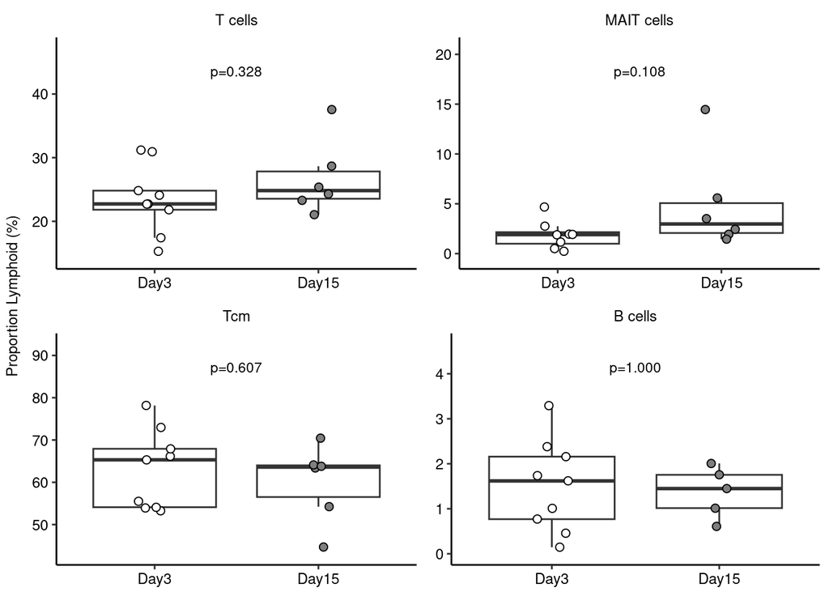

```r
lymph_subpop <- c("T cells", "MAIT cells", "Tcm", "B cells")

lymph_plots <- purrr::pmap(.l = list(lymph_subpop),
                           .f = function(n) {
                           make_boxplot(lymph_df, current_cluster = n)
                         })

names(lymph_plots) <- lymph_subpop
lymphgrid <- ggarrange(plotlist = lymph_plots, nrow = 2, ncol = 2)
lymphgrid <- annotate_figure(lymphgrid, left = text_grob("Proportion Lymphoid (%)", rot = 90, size = 9))
lymphgrid
```

Myeloid

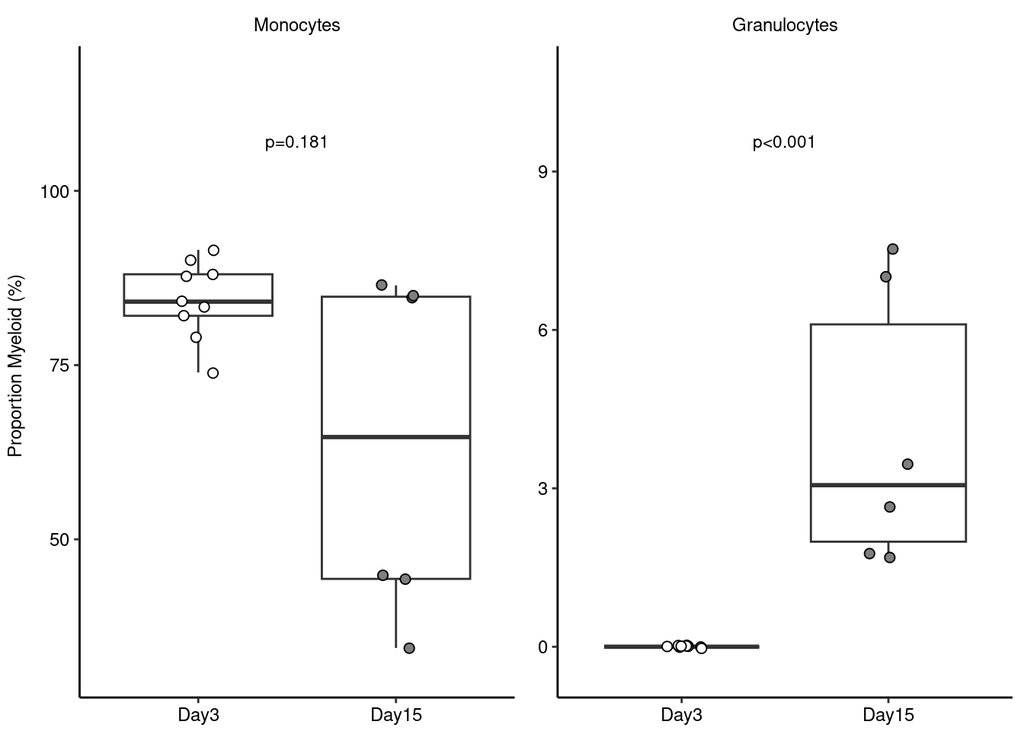

```r
myel_subpop <- c("Monocytes", "Granulocytes")

myel_plots <- purrr::pmap(.l = list(myel_subpop),
                           .f = function(n) {
                           make_boxplot(myel_df, current_cluster = n)
                         })
names(myel_plots) <- myel_subpop
myelgrid <- ggarrange(plotlist = myel_plots, nrow = 1, ncol = 2)
myelgrid <- annotate_figure(myelgrid, left = text_grob("Proportion Myeloid (%)", rot = 90, size = 9))
myelgrid
```

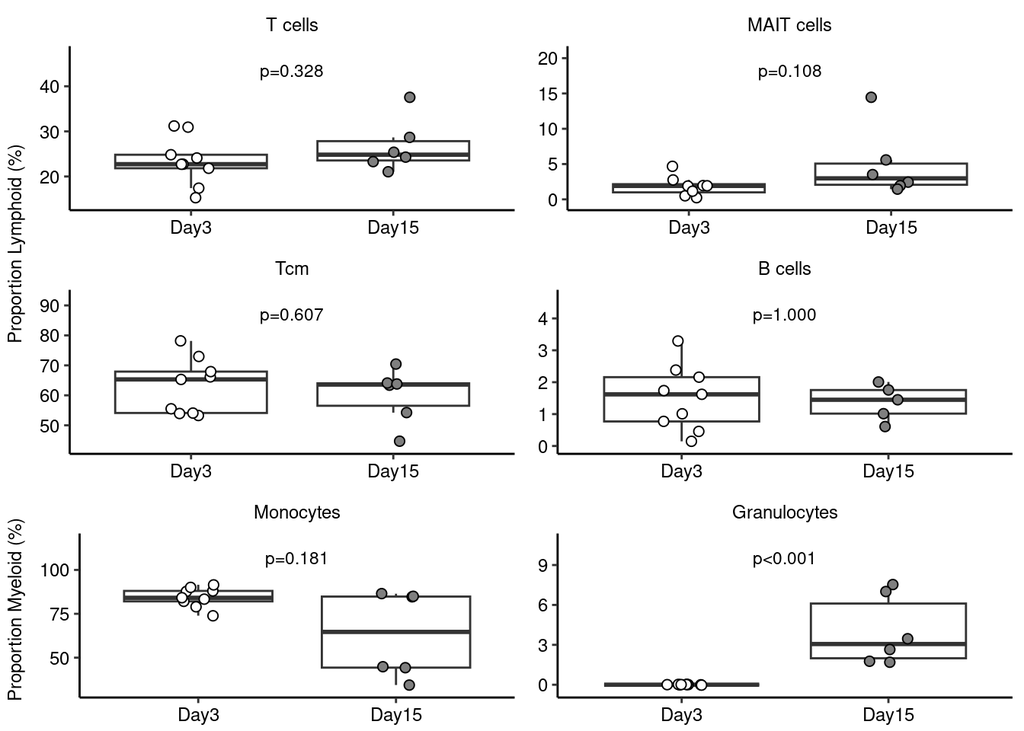

```r
composition_grid <- plot_grid(lymphgrid, myelgrid, ncol = 1, rel_heights = c(2, 1))
composition_grid
```

```r
ggsave(file.path(script_output_dir, "plots/Fig5_boxplots.png"), plot = composition_grid,
       dpi = 300, width = 3, height = 4.5, device = "png")

cairo_pdf(file = file.path(script_output_dir, "plots/Fig5_boxplots.pdf"),
          width = 3, height = 4.5, bg = "transparent", family = "Arial")
print(composition_grid)
dev.off()
```

# CellChat: Immune-level annotations

## Prepare data

Log normalize and choose database.

```r
if (rerun_cellchat) {
  DefaultAssay(day3_annot) <- "RNA"
  DefaultAssay(day15_annot) <- "RNA"

  # Log-normalize
  day3_annot <- NormalizeData(day3_annot)
  day15_annot <- NormalizeData(day15_annot)

  # Create CellChat object
  day3_cellchat_imm <- createCellChat(day3_annot, group.by = "cytof_annot")
  day15_cellchat_imm <- createCellChat(day15_annot, group.by = "cytof_annot")

  # Set the interaction database and add to the object
  day3_cellchat_imm@DB <- CellChatDB.human
  day15_cellchat_imm@DB <- CellChatDB.human
}
```

Subset GEX data to just genes in the signalling pathways database (to save time).

```r
if (rerun_cellchat) {
  # Subset the expression data of signaling genes for saving computation cost.
  # This step is necessary even if using the whole database
  day3_cellchat_sub_imm <- subsetData(day3_cellchat_imm)
  day15_cellchat_sub_imm <- subsetData(day15_cellchat_imm)
}
```

Identify over-expressed **signaling genes** associated with each cell group.

Default settings being used by `identifyOverExpressedGenes`: - Only returns positive markers (only.pos=TRUE) - LogFC threshold is 0 (thresh.fc = 0) - p-value threshold is 0.05 (thresh.p = 0.05) - Only use genes if they’re expressed in at least 10 cells total in the dataset - Need at least 10 ‘expressed’ cells in the whole dataset for the genes to be considered for cell-cell communication analysis (min.cells = 10)

```r
if (rerun_cellchat) {
  # Parallelize
  future::plan("multisession", workers = 12)

  day3_cellchat_sub_imm <- identifyOverExpressedGenes(day3_cellchat_sub_imm)
  day15_cellchat_sub_imm <- identifyOverExpressedGenes(day15_cellchat_sub_imm)
}
```

Identify over-expressed **ligand-receptor interactions** (pairs) within the used CellChatDB

Default settings being used by `identifyOverExpressedInteractions`: - Require that both ligand and receptor from one pair are over-expressed (variable.both = TRUE)

```r
if (rerun_cellchat) {
  day3_cellchat_sub_imm <- identifyOverExpressedInteractions(day3_cellchat_sub_imm)
  day15_cellchat_sub_imm <- identifyOverExpressedInteractions(day15_cellchat_sub_imm)
}
```

## Infer cell-cell communication network (takes a while)

Compute the communication probability/strength between any interacting cell groups

Non-default settings being used by `computeCommunProb`: - Consider the proportion of cells in each group across all sequenced cells. They advise in the docs “Set population.size = TRUE if analyzing unsorted single-cell transcriptomes, with the reason that abundant cell populations tend to send collectively stronger signals than the rare cell populations.”

```r
if (rerun_cellchat) {
  # Day 3
  day3_cellchat_sub_imm <- computeCommunProb(day3_cellchat_sub_imm, type = "triMean",
                                         population.size = TRUE)  # Consider effect of cell proportion
  day3_cellchat_sub_imm <- filterCommunication(day3_cellchat_sub_imm)  # Exclude if <10 cells in a group (default)
  # Save
  saveRDS(day3_cellchat_sub_imm, file = file.path(script_output_dir, "processed_data/10_cellchat_d3_imm.rds"))

  # Day 15
  day15_cellchat_sub_imm <- computeCommunProb(day15_cellchat_sub_imm, type = "triMean",
                                          population.size = TRUE)  # Consider effect of cell proportion
  day15_cellchat_sub_imm <- filterCommunication(day15_cellchat_sub_imm)  # Exclude if <10 cells in a group (default)
  # Save
  saveRDS(day15_cellchat_sub_imm, file = file.path(script_output_dir, "processed_data/10_cellchat_d15_imm.rds"))
}
```

## Analyze communication networks

```r
day3_cellchat_sub_imm <- readRDS(file = file.path(script_output_dir, "processed_data/10_cellchat_d3_imm.rds"))
day15_cellchat_sub_imm <- readRDS(file = file.path(script_output_dir, "processed_data/10_cellchat_d15_imm.rds"))

# Define color of cell types in plots
clstr_colors_imm <- c("Lymphoid other" = "#00A9FF", "T cells"= "#00BFC4", "MAIT cells" = "cyan",
                  "Tcm" = "#8ab8fe", "B cells" = "navy", "Keratinocytes" = "#FF61CC",
                  "Epithelial" = "#0CB702", "Endothelial" = "#E68613",
                  "Muscle tissue" = "#C77CFF", "Connective tissue" = "#00BE67",
                  "Nervous tissue" = "#A52A2A", "Unknown" = "gray",
                  "Myeloid other" = "#F8766D", "Monocytes" = "#cb416b",
                  "Granulocytes" = "#f8481c")

# Define order cell types appear in plots
new_levels_imm <- c("Lymphoid other", "T cells", "MAIT cells", "Tcm", "B cells",
                "Keratinocytes", "Epithelial", "Endothelial", "Muscle tissue",
                "Connective tissue", "Nervous tissue", "Unknown", "Myeloid other",
                "Monocytes", "Granulocytes")

day3_cellchat_sub_imm <- setIdent(day3_cellchat_sub_imm, ident.use = "cytof_annot", levels = new_levels_imm[1:14])
```

```
## Reorder cell groups!
```

```
## The cell group order before reordering is  B cells Connective tissue Endothelial Epithelial Keratinocytes Lymphoid other MAIT cells Monocytes Muscle tissue Myeloid other Nervous tissue T cells Tcm Unknown
## The cell group order after reordering is  Lymphoid other T cells MAIT cells Tcm B cells Keratinocytes Epithelial Endothelial Muscle tissue Connective tissue Nervous tissue Unknown Myeloid other Monocytes
```

```r
day15_cellchat_sub_imm <- setIdent(day15_cellchat_sub_imm, ident.use = "cytof_annot", levels = new_levels_imm)
```

```
## Reorder cell groups!
```

```
## The cell group order before reordering is  B cells Connective tissue Endothelial Epithelial Granulocytes Keratinocytes Lymphoid other MAIT cells Monocytes Muscle tissue Myeloid other Nervous tissue T cells Tcm Unknown
## The cell group order after reordering is  Lymphoid other T cells MAIT cells Tcm B cells Keratinocytes Epithelial Endothelial Muscle tissue Connective tissue Nervous tissue Unknown Myeloid other Monocytes Granulocytes
```

**Day 3**

Not interested in any of the ECM (extra-cellular matrix) pathways. Mark those for exclusion later when aggregating communication signal.

```r
to_incl <- day3_cellchat_sub_imm@LR$LRsig %>%
  select(annotation, pathway_name) %>%
  filter(!annotation == "ECM-Receptor") %>%
  pull(pathway_name) %>%
  unique()
length(to_incl)
```

```
## [1] 231
```

Circos plots

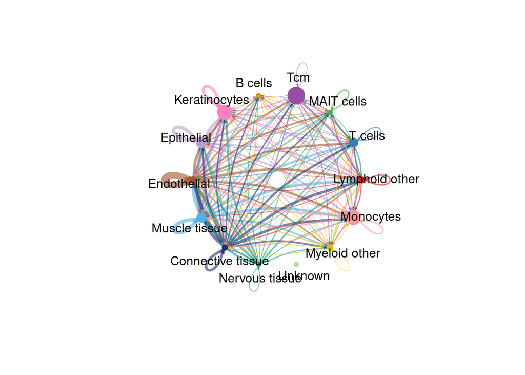

```r
# Get aggregated network by counting the number of links or summarizing the communication probability
day3_cellchat_sub_imm <- aggregateNet(day3_cellchat_sub_imm, signaling = to_incl,
                                      remove.isolate = FALSE)

groupSize <- as.numeric(table(day3_cellchat_sub_imm@idents))

# Visualize aggregated network 'weighted' by number of interactions
netVisual_circle(day3_cellchat_sub_imm@net$count,
                 vertex.weight = groupSize,
                 weight.scale = T,
                 label.edge = F,
                 title.name = "Day 3: Number of interactions")
```

```r
# Visualize aggregated network weighted by strength of interactions
d3_circle_imm <- netVisual_circle(day3_cellchat_sub_imm@net$weight,
                 vertex.weight = groupSize,
                 weight.scale = T,
                 label.edge = F,
                 title.name = "Day 3",
                 color.use = clstr_colors_imm[1:14],
                 alpha.edge = 0.8)
```

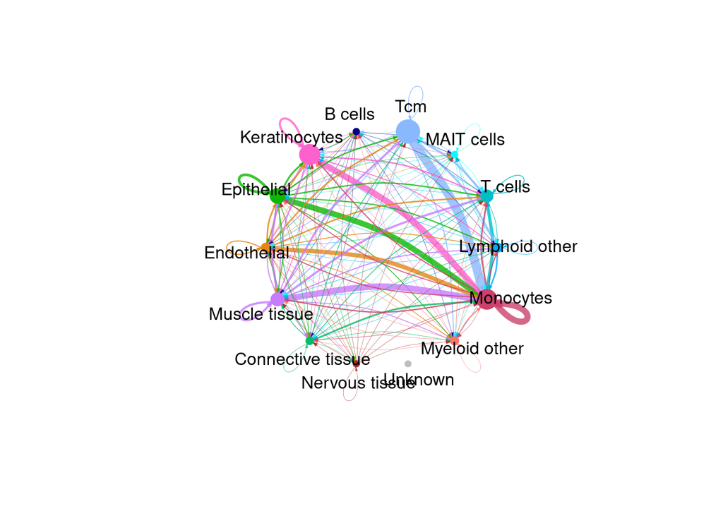

```r
d3_circle_imm

# Save
cairo_pdf(file = file.path(script_output_dir, "plots/Fig5_d3_cellchat.pdf"),
          width=5, height=5,
          onefile = TRUE, bg = "transparent", family = "Arial")
print(d3_circle_imm)
dev.off()
```

Table of interactions (all)

```r
d3_tbl_imm <- netVisual_bubble(day3_cellchat_sub_imm,
                 remove.isolate = FALSE,
                 return.data = TRUE)$communication %>%
  mutate(timepoint = "Day3") %>%
  select(timepoint, source.target, ligand, receptor, interaction_name, prob,
         pval, pathway_name, annotation) %>%
  arrange(desc(prob)) %>%
  distinct()
```

```
## Comparing communications on a single object
```

```r
# Remove extra-cellular matrix pathways
d3_tbl_no_ecm_imm <- d3_tbl_imm %>%
  filter(annotation != "ECM-Receptor")
```

**Day 15**

Circos plots

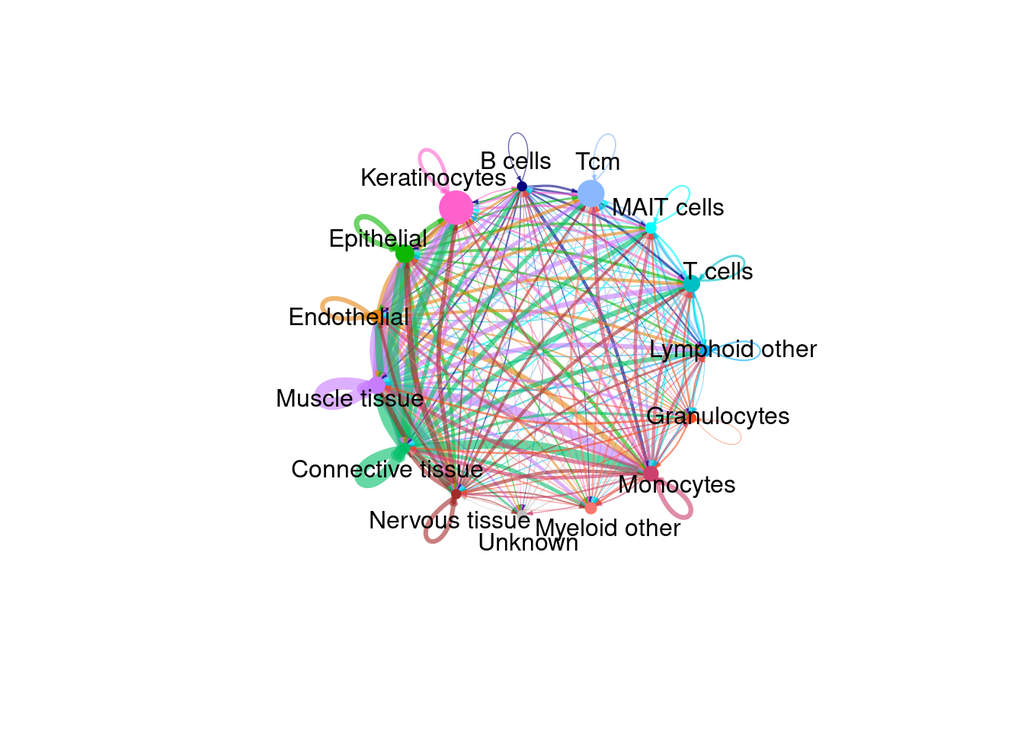

```r
# Get aggregated network by counting the number of links or summarizing the communication probability
day15_cellchat_sub_imm <- aggregateNet(day15_cellchat_sub_imm)

groupSize <- as.numeric(table(day15_cellchat_sub_imm@idents))

# Visualize aggregated network 'weighted' by number of interactions
netVisual_circle(day15_cellchat_sub_imm@net$count,
                 vertex.weight = groupSize,
                 weight.scale = T,
                 label.edge= F,
                 title.name = "Day 15: Number of interactions",
                 color.use = clstr_colors_imm)
```

```r
# Visualize aggregated network weighted by strength of interactions
d15_circle_imm <- netVisual_circle(day15_cellchat_sub_imm@net$weight,
                 vertex.weight = groupSize,
                 weight.scale = T,
                 label.edge= F,
                 title.name = "Day 15",
                 color.use = clstr_colors_imm,
                 alpha.edge = 0.8)
```

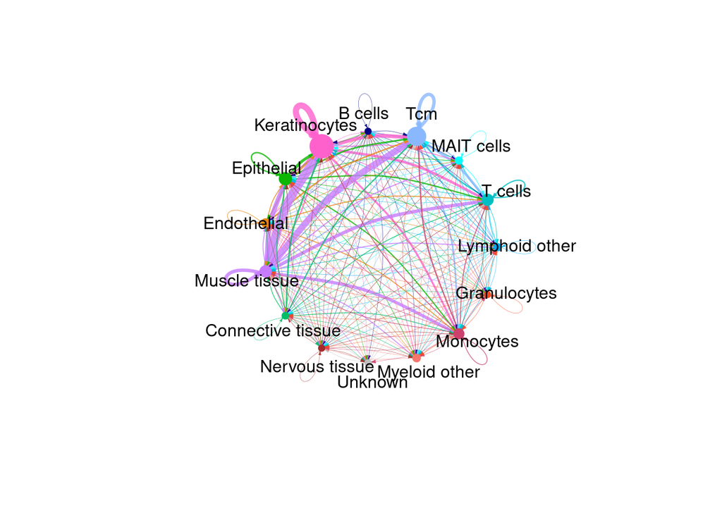

```r
d15_circle_imm

# Save
cairo_pdf(file = file.path(script_output_dir, "plots/Fig5_d15_cellchat.pdf"),
          width=5, height=5,
          onefile = TRUE, bg = "transparent", family = "Arial")
print(d15_circle_imm)
dev.off()
```

Table of interactions (all)

```r
d15_tbl_imm <- netVisual_bubble(day15_cellchat_sub_imm,
                 return.data = TRUE)$communication %>%
  mutate(timepoint = "Day15") %>%
  select(timepoint, source.target, ligand, receptor, interaction_name, prob,
         pval, pathway_name, annotation) %>%
  arrange(desc(prob)) %>%
  distinct()
```

```
## Comparing communications on a single object
```

```r
# Remove extra-cellular matrix pathways
d15_tbl_no_ecm_imm <- d15_tbl_imm %>%
  filter(annotation != "ECM-Receptor")
```

## Examine interactions

Fyi, pval == 2 means p-value > 0.05 (inferred from dot size of bubble plot and the legend)

```r
# Show pathways involved in top X interactions at each day involving monocytes at days 3 and 15
bubble_df <- bind_rows(d3_tbl_no_ecm_imm, d15_tbl_no_ecm_imm) %>%
  filter(grepl("Monocytes", source.target)) %>%
  group_by(timepoint) %>%
  arrange(desc(prob)) %>%
  slice_head(n = 20) %>%
  ungroup() %>%
  select(interaction_name) %>%
  distinct() %>%
  # Keep only the 'hottest' interactions
  filter(!interaction_name %in% c("CD99_CD99", "CD99_PILRA",
                                  "APP_CD74", "EREG_EGFR",
                                  "PPIA_BSG"))

source_target <- c("Keratinocytes", "Tcm", "Muscle tissue", "Endothelial",
                   "Epithelial", "Monocytes", "T cells")


# Day 3: Monocytes are source
d1 <- netVisual_bubble(day3_cellchat_sub_imm,
                 color.heatmap = "viridis",
                 sources.use = "Monocytes",
                 targets.use = source_target,
                 pairLR.use = bubble_df,
                 angle.x = 45,
                 title.name = "Day 3") +
  coord_flip()
```

```
## Comparing communications on a single object
```

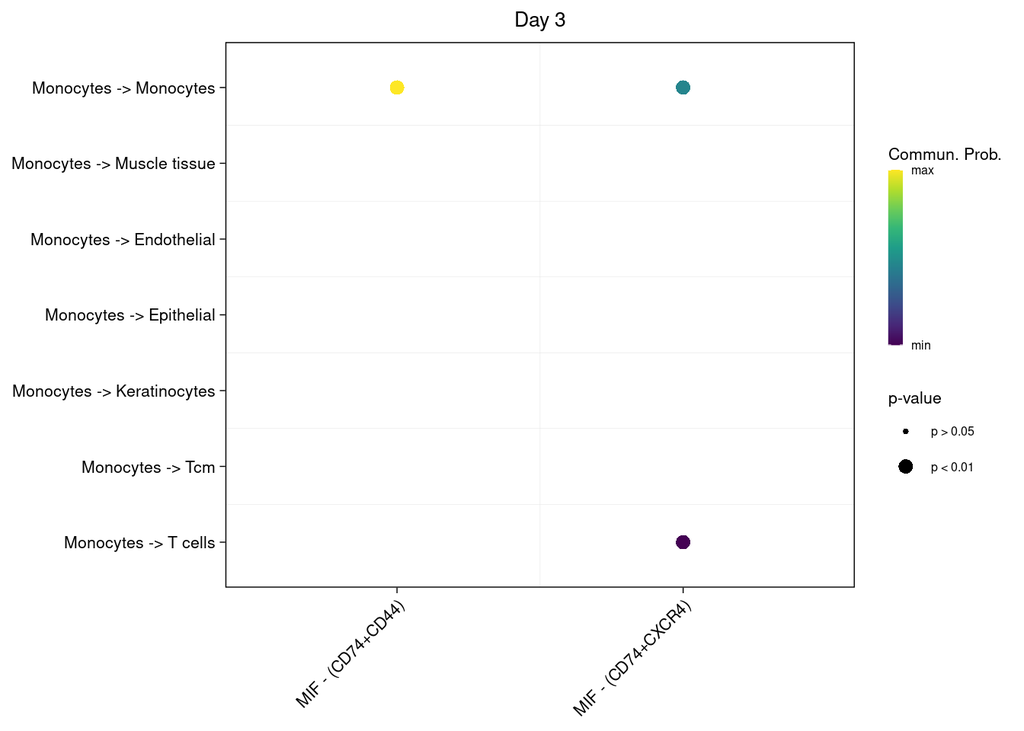

```r
d1
```

```r
# Day 15: Monocytes are source
d2 <- netVisual_bubble(day15_cellchat_sub_imm,
                 color.heatmap = "viridis",
                 sources.use = "Monocytes",
                 targets.use = source_target,
                 pairLR.use = bubble_df,
                 angle.x = 45,
                 title.name = "Day 15") +
  coord_flip()
```

```
## Comparing communications on a single object
```

```r
# Day 3: Monocytes are target
d3 <- netVisual_bubble(day3_cellchat_sub_imm,
                 color.heatmap = "viridis",
                 sources.use = source_target,
                 targets.use = "Monocytes",
                 pairLR.use = bubble_df,
                 angle.x = 45,
                 title.name = "Day 3") +
  coord_flip()
```

```
## Comparing communications on a single object
```

```r
# Day 15: Monocytes are target
d4 <- netVisual_bubble(day15_cellchat_sub_imm,
                 color.heatmap = "viridis",
                 sources.use = source_target,
                 targets.use = "Monocytes",
                 pairLR.use = bubble_df,
                 angle.x = 45,
                 title.name = "Day 15") +
  coord_flip()
```

```
## Comparing communications on a single object
```

# Module expression

Extract just the immune cells

First subset and remove current normalized counts

```r
Idents(day3_annot) <- "eb_atlas_idents"
day3_sub <- subset(day3_annot, idents = c("Lymphoid", "Myeloid"))
DefaultAssay(day3_sub) <- "RNA"
day3_sub[["SCT"]] <- NULL

Idents(day15_annot) <- "eb_atlas_idents"
day15_sub <- subset(day15_annot, idents = c("Lymphoid", "Myeloid"))
DefaultAssay(day15_sub) <- "RNA"
day15_sub[["SCT"]] <- NULL
```

Then normalize and reduce dimensions again

```r
norm_and_reduce <- function(dm_singlets) {
  dm_singlets <- SCTransform(dm_singlets,
                             vars.to.regress = "percent.mt",
                             verbose = FALSE)
  dm_singlets <- RunPCA(dm_singlets, verbose = FALSE)
  dm_singlets <- FindNeighbors(dm_singlets, dims = 1:30)
  dm_singlets <- RunUMAP(dm_singlets, dims = 1:30)
  return(dm_singlets)
}

day3_sub <- norm_and_reduce(day3_sub)
```

```
## Found more than one class "dist" in cache; using the first, from namespace 'spam'
```

```
## Also defined by 'BiocGenerics'
```

```
## Found more than one class "dist" in cache; using the first, from namespace 'spam'
```

```
## Also defined by 'BiocGenerics'
```

```r
day15_sub <- norm_and_reduce(day15_sub)
```

```
## Found more than one class "dist" in cache; using the first, from namespace 'spam'
## Also defined by 'BiocGenerics'
## Found more than one class "dist" in cache; using the first, from namespace 'spam'
## Also defined by 'BiocGenerics'
```

```r
Idents(day3_sub) <- "cytof_annot"
Idents(day15_sub) <- "cytof_annot"

# Re-level object@ident
pop_levels_d3 <- c("T cells", "MAIT cells", "Tcm", "B cells", "Lymphoid other", "Monocytes", "Myeloid other")
pop_levels_d15 <- c("T cells", "MAIT cells", "Tcm", "B cells", "Lymphoid other", "Monocytes", "Myeloid other", "Granulocytes")

day3_sub@active.ident <- factor(x = day3_sub@active.ident, levels = pop_levels_d3)
day15_sub@active.ident <- factor(x = day15_sub@active.ident, levels = pop_levels_d15)

# Define colors
pop_colors <- c("Lymphoid other" = "#00A9FF", "T cells"= "#00BFC4", "MAIT cells" = "cyan",
                  "Tcm" = "#8ab8fe", "B cells" = "blue",
                  "Myeloid other" = "#F8766D", "Monocytes" = "#cb416b",
                  "Granulocytes" = "#f8481c")
```

## Violin plots of module score

```r
# Gene modules to highlight
enriched_neutr <- c('LIN7A','NCF4','EMR3','FCGR3A','S100P','FCGR3B','TNFRSF10C','C5AR1',
                    'MGC31957','CHI3L1','NLRP12','CYP4F3','MXD1','SEPX1','MGAM','DGAT2',
                    'RGL4','REPS2','VNN2','CXCR1','NFE2','KRT23','GPR109B','PYGL','FPR2',
                    'G0S2','KCNJ15','LRRC4','FPR1','CREB5','FCGR2A','CMTM2','MANSC1',
                    'CSF3R','FFAR2','RNF24','LRG1','ST6GALNAC2','ORM1','MME','CDA',
                    'PROK2','PFKFB4','VNN3','SLC22A4','BASP1','TREM1','GLT1D1','GPR97',
                    'PTAFR','STEAP4','ALPL','NPL','ARAP3','HSPA6','TYROBP','CFD','IMPA2',
                    'DENND3','BTNL8','FRAT2','MBOAT7','TSPAN2','BEST1','FLJ10357','SLC40A1')

enriched_mono <- unique(c('TNFSF13','MYCL1','EPB41L3','DPYSL2','RTN1','SLC31A2','FES','LGALS3',
                    'HCK','APLP2','LGALS1','PTGS2','EMR1','AMICA1','DOCK5','CD4','LY96',
                    'ARHGEF10L','TNFSF13B','LTBR','PGD','TNFRSF1B','LRRK2','DPYD','MGAM',
                    'PTX3','LYZ','IL1R2','DOK3','CARD9','EVI5','GPR109B','DUSP6','MYO1F',
                    'FGD4','HHEX','HAL','ST3GAL6','DYSF','RNASE6','SLC24A4','VNN1','NAIP',
                    'RHOU','CD68','CXCR2','NACC2','SMARCD3','PADI4','TMEM176B','LGALS3',
                    'SAMHD1','CTSS','EMILIN2','ACPP','F5','STEAP4','C19orf59','ACSL1',
                    'PAK1','C1orf162','MOSC1','TLR1','PID1','BCL6','HLA-DMB','MPP1','AGPAT9'))

modules <- list(enriched_neutr, enriched_mono)
```

Add module scores

```r
day3_sub_t <- AddModuleScore(object = day3_sub, features = modules,
                             search = T, nbin = 18,
                             name = "Module")

day15_sub_t <- AddModuleScore(object = day15_sub, features = modules,
                             search = T, nbin = 18,
                             name = "Module")
```

Combine and save

```r
combined <- merge(day3_sub_t, day15_sub_t)

combined@meta.data <- combined@meta.data %>%
  mutate(orig.ident = factor(orig.ident, levels = c("Day3", "Day15")))

saveRDS(combined, file = file.path(script_output_dir, "processed_data/11_combined_modules.rds"))
```

Violin plots

```r
neutr_vln <- VlnPlot(combined, "Module1", split.by = "orig.ident",
        cols = c("Day3" = "white", "Day15" = "gray50"), pt.size = 0) +
  ylim(-0.17, 0.52) +
  theme(axis.title.x = element_blank(),
        axis.text.x = element_text(size = 9),
        axis.text.y = element_text(size = 9),
        legend.text = element_text(size = 9),
        legend.position = c(0.05, 0.9),
        legend.key.size = unit(0.3, "cm"),
        plot.title = element_text(hjust = 0.5, face = "plain", size = 9)) +
  ggtitle("Neutrophils (I, II)")
```

```
## The default behaviour of split.by has changed.
## Separate violin plots are now plotted side-by-side.
## To restore the old behaviour of a single split violin,
## set split.plot = TRUE.
##
## This message will be shown once per session.
```

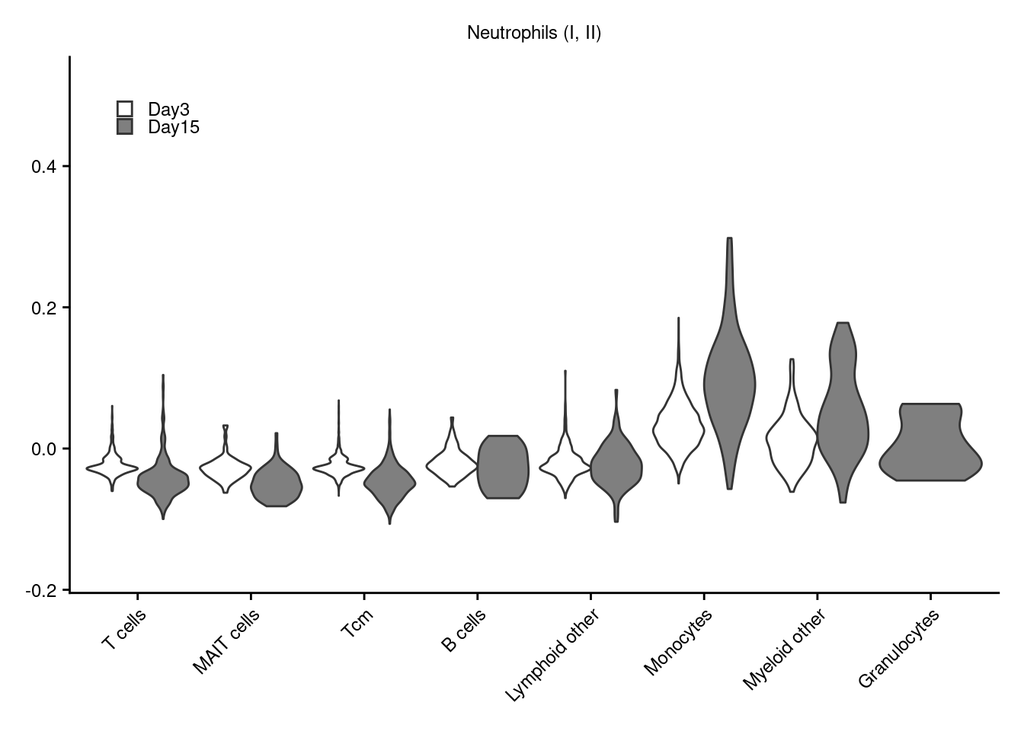

```r
neutr_vln
```

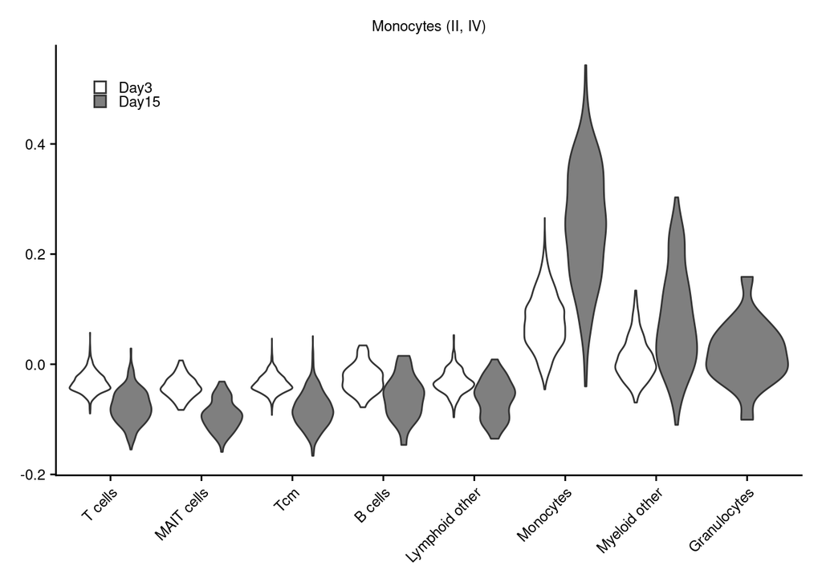

```r
mono_vln <- VlnPlot(combined, "Module2", split.by = "orig.ident",
        cols = c("Day3" = "white", "Day15" = "gray50"), pt.size = 0) +
  theme(axis.title.x = element_blank(),
        axis.text.x = element_text(size = 9),
        axis.text.y = element_text(size = 9),
        legend.text = element_text(size = 9),
        legend.position = c(0.05, 0.9),
        legend.key.size = unit(0.3, "cm"),
        plot.title = element_text(hjust = 0.5, face = "plain", size = 9)) +
  ggtitle("Monocytes (II, IV)")
mono_vln
```

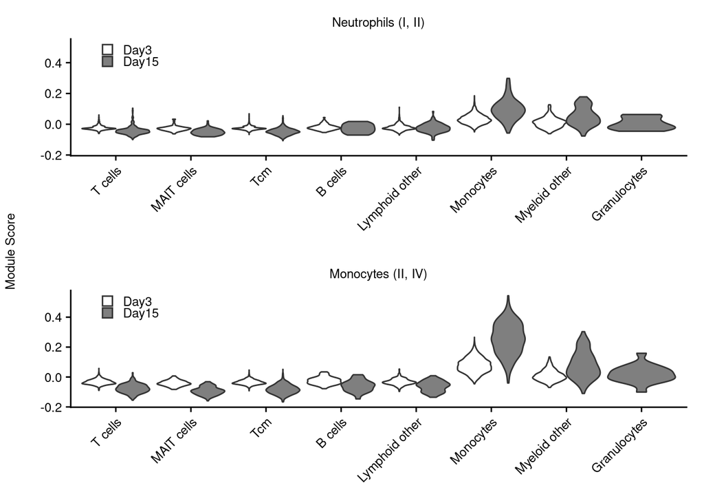

```r
grid_vln <- ggarrange(plotlist = list(neutr_vln, mono_vln), nrow = 2, ncol = 1) %>%
  annotate_figure(left = text_grob("Module Score", rot = 90, size = 9))
grid_vln
```

```r
# Save
ggsave(file.path(script_output_dir, "plots/Fig5_violin.png"), plot = grid_vln,
       dpi = 300, width = 3.5, height = 5, device = "png")

cairo_pdf(file = file.path(script_output_dir, "plots/Fig5_violin.pdf"),
          width = 3.5, height = 5, bg = "transparent", family = "Arial")
print(grid_vln)
dev.off()
```